# Atividade Prática 3 — Respostas

Econometria Aplicada à Finanças  
Mestrado Profissional em Administração

Autor

Jonathan Vargas Silva

Data de Publicação

18 de agosto de 2026

## Questão 1 — Simulando dados de um modelo homocedástico

```r
# Fixa a semente para tornar a simulação reproduzível
set.seed(12345)

# Define o tamanho da amostra e os parâmetros populacionais
n <- 500
beta_0 <- 1
beta_1 <- 3
sigma <- 2

# Gera o regressor e o termo de erro homocedástico
x <- runif(n, min = -3, max = 3)
erro <- rnorm(n, mean = 0, sd = sigma)

# Calcula a variável dependente segundo o modelo populacional
y <- beta_0 + beta_1 * x + erro

# Organiza as variáveis simuladas
dados_homo <- tibble(x, erro, y)

# Estima o modelo por MQO
modelo_homo <- lm(y ~ x, data = dados_homo)

# Apresenta as estimativas dos coeficientes
broom::tidy(modelo_homo)
```

```
# A tibble: 2 × 5
  term        estimate std.error statistic   p.value
  <chr>          <dbl>     <dbl>     <dbl>     <dbl>
1 (Intercept)     1.08    0.0896      12.0 2.48e- 29
2 x               3.03    0.0514      58.9 2.12e-226
```

**a.** Identifique os parâmetros populacionais, as variáveis aleatórias e as estimativas calculadas com a amostra. Diferencie `beta_1` do coeficiente de `x` retornado por `lm()`.

**b.** Compare as estimativas com os parâmetros populacionais. Explique por que elas não precisam ser exatamente iguais aos parâmetros.

As estimativas não precisam ser iguais aos parâmetros populacionais porque a amostra é apenas uma realização aleatória entre muitas possíveis.

**c.** Execute o gráfico e explique o que representam os pontos, a reta e a dispersão vertical em torno dela.

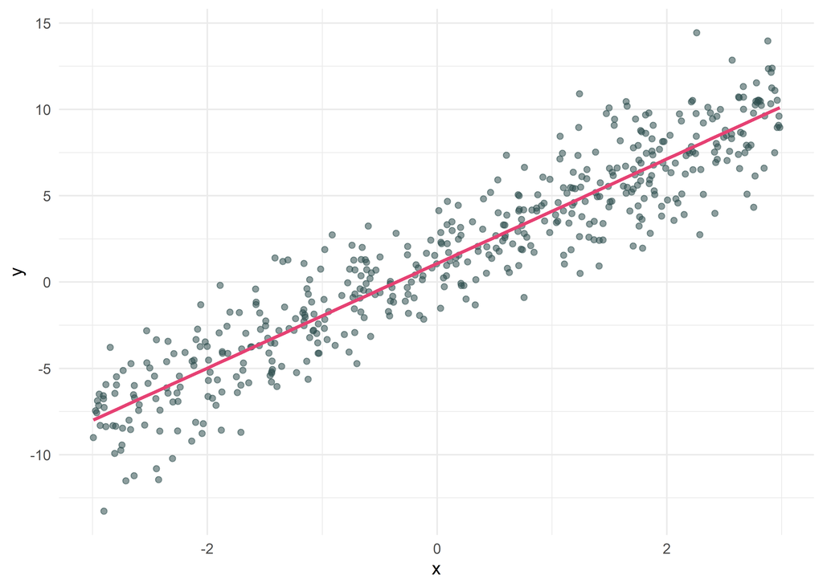

Amostra simulada e reta de regressão estimada no modelo homocedástico.

```r
# Representa os dados e acrescenta a reta estimada por MQO
ggplot(dados_homo, aes(x = x, y = y)) +
  geom_point(color = "darkslategrey", alpha = 0.55) +
  geom_smooth(method = "lm", formula = y ~ x, se = FALSE, color = "#E64173") +
  labs(x = "x", y = "y") +
  theme_minimal()
```

Os pontos representam os pares observados (x, y) da amostra simulada. A reta representa a relação estimada por MQO. A dispersão vertical dos pontos em torno da reta reflete a influência do erro sobre y.

**d.** Explique por que a simulação ajuda a avaliar um procedimento econométrico e por que uma única amostra não demonstra uma propriedade geral do estimador.

A simulação ajuda porque, ao contrário de dados reais, os parâmetros populacionais verdadeiros são conhecidos e é possível verificar se o MQO consegue representá-los. Entretanto, uma única amostra é apenas uma realização aleatória entre muitas possíveis.

## Questão 2 — Simulando dados de um modelo heterocedástico

**a.** Execute a simulação e examine o intervalo dos desvios-padrão.

```r
# Fixa a semente e define o modelo populacional
set.seed(12345)
n <- 500
beta_0 <- 1
beta_1 <- 3

# Gera o regressor
x <- runif(n, min = -3, max = 3)

# Define um desvio-padrão que aumenta com x
sigma_i <- 5 + 1.5 * x

# Interrompe a execução se algum desvio-padrão não for positivo
stopifnot(all(sigma_i > 0))

# Gera os erros e a variável dependente
erro <- rnorm(n, mean = 0, sd = sigma_i)
y <- beta_0 + beta_1 * x + erro

# Organiza as variáveis simuladas
dados_hetero <- tibble(x, sigma_i, erro, y)

# Verifica o intervalo dos desvios-padrão simulados
range(dados_hetero$sigma_i)
```

```
[1] 0.51023 9.47297
```

Confirme que o intervalo observado é coerente com o intervalo teórico.

**b.** Execute o gráfico dos erros verdadeiros. Explique por que o funil indica mudança da variância condicional, e não necessariamente da média condicional dos erros.

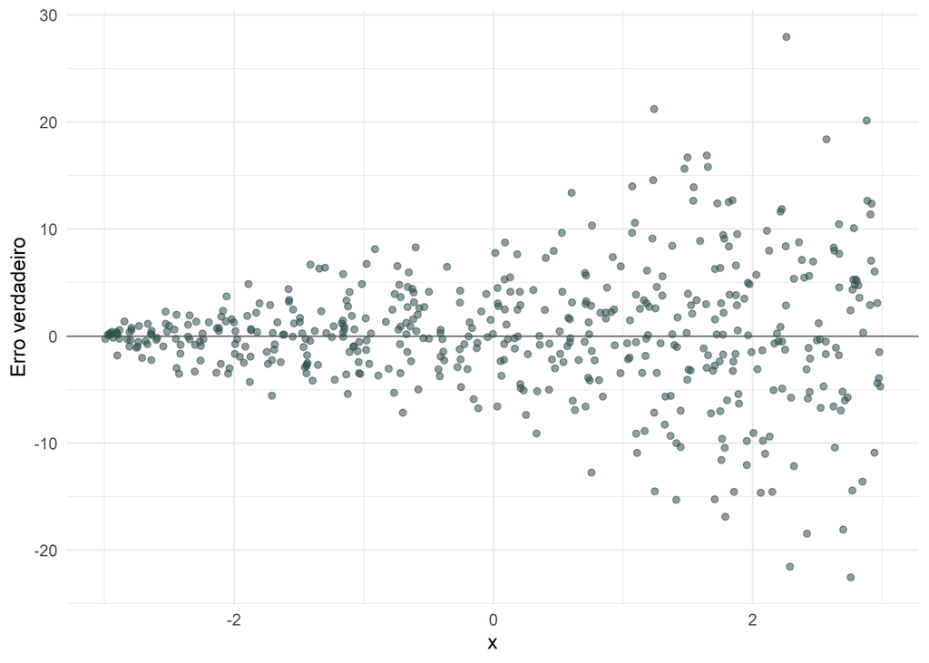

Erros verdadeiros no modelo heterocedástico simulado.

```r
# Representa os erros verdadeiros em função do regressor
ggplot(dados_hetero, aes(x = x, y = erro)) +
  geom_hline(yintercept = 0, linewidth = 0.4, color = "grey45") +
  geom_point(color = "darkslategrey", alpha = 0.55) +
  labs(x = "x", y = "Erro verdadeiro") +
  theme_minimal()
```

**c.** Estime o modelo, compare as estimativas com os parâmetros populacionais e explique por que os erros verdadeiros não são idênticos aos resíduos.

```r
# Estima o modelo por MQO
modelo_hetero <- lm(y ~ x, data = dados_hetero)

# Apresenta as estimativas dos coeficientes
broom::tidy(modelo_hetero)
```

```
# A tibble: 2 × 5
  term        estimate std.error statistic  p.value
  <chr>          <dbl>     <dbl>     <dbl>    <dbl>
1 (Intercept)     1.26     0.266      4.75 2.70e- 6
2 x               3.05     0.153     20.0  1.45e-65
```

```r
# Acrescenta resíduos e valores ajustados à base simulada
dados_hetero <- dados_hetero |>
  mutate(
    residuo = residuals(modelo_hetero),
    ajustado = fitted(modelo_hetero)
  )

# Compara os erros e os resíduos das seis primeiras observações
dados_hetero |>
  select(erro, residuo) |>
  slice_head(n = 6)
```

```
# A tibble: 6 × 2
    erro residuo
   <dbl>   <dbl>
1  -5.65   -5.99
2   8.39    8.00
3   3.35    3.00
4 -12.2   -12.5
5  -1.22   -1.47
6   1.28    1.12
```

As estimativas ficaram próximas dos parâmetros verdadeiros, mas os erros-padrão são maiores que no modelo, porque o resíduo depende dos coeficientes estimados, que mudam de uma amostra para outra.

**d.** Execute o gráfico `Residuals vs Fitted` e escreva uma interpretação clara e objetiva, com três a cinco frases.

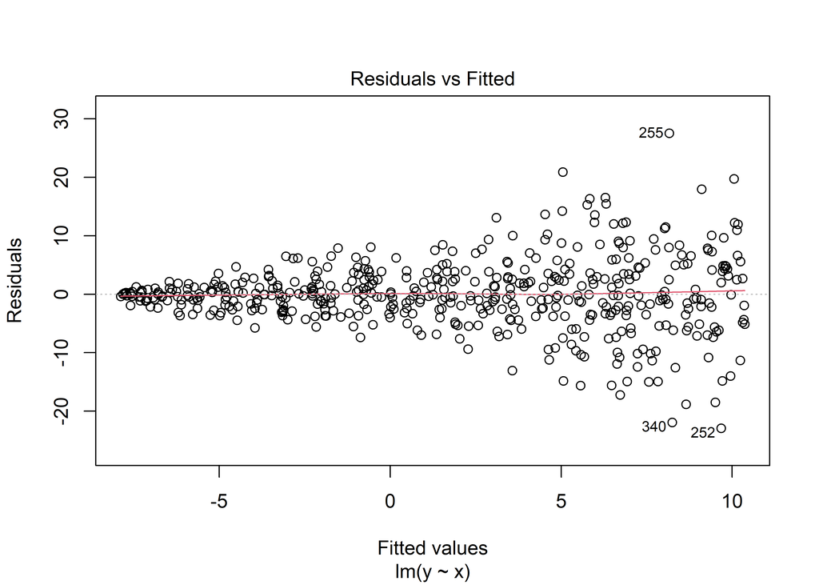

Resíduos contra valores ajustados no modelo heterocedástico.

```r
# Seleciona o gráfico Residuals vs Fitted
plot(modelo_hetero, which = 1)
```

A posição dos resíduos em relação a zero se distancia ao longo do eixo `x`. A sua dispersão vertical não permanece aproximadamente constante e, por isso o padrão observado não é compatível com homocedasticidade, visto que o gráfico representa um formato de funil, que é um claro exemplo de heterocedasticidade.

**e.** Explique se a heterocedasticidade, isoladamente, torna os estimadores de MQO viesados neste processo gerador. Use em sua justificativa a hipótese $E(\varepsilon_i\mid x_i)=0$.

## Questão 3 — Compreendendo o teste de White

**a.** Execute a simulação e examine o gráfico `Residuals vs Fitted`. Explique por que o padrão é coerente com variância menor perto de $x=0$ e maior para valores de $x$ mais afastados de zero.

```r
# Fixa a semente e define o modelo populacional
set.seed(12345)
n <- 500
beta_0 <- 1
beta_1 <- 3

# Gera o regressor e define o desvio-padrão condicional
x <- runif(n, min = -3, max = 3)
sigma_i <- 2 + x^2

# Interrompe a execução se algum desvio-padrão não for positivo
stopifnot(all(sigma_i > 0))

# Gera os erros e calcula a variável dependente
erro <- rnorm(n, mean = 0, sd = sigma_i)
y <- beta_0 + beta_1 * x + erro

# Organiza a amostra e estima o modelo por MQO
dados_extremos <- tibble(x, sigma_i, erro, y)
modelo_extremos <- lm(y ~ x, data = dados_extremos)

# Acrescenta os resíduos à base
dados_extremos <- dados_extremos |>
  mutate(residuo = residuals(modelo_extremos))
```

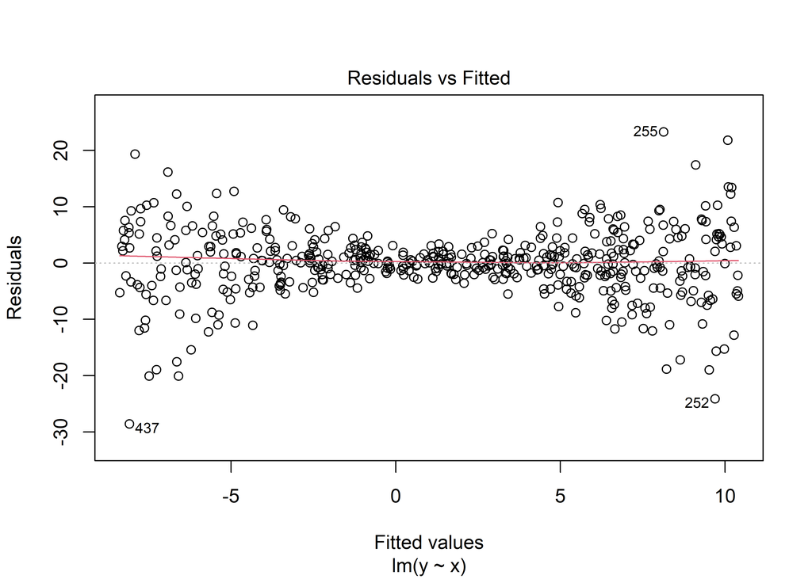

Resíduos contra valores ajustados no modelo com funil duplo.

```r
# Seleciona o gráfico Residuals vs Fitted
plot(modelo_extremos, which = 1)
```

Perto de $x=0$, os resíduos ficam concentrados perto de zero, formando uma faixa estreita. Nos dois extremos de x, a dispersão aumenta. Isso é coerente com o processo gerador porque o desvio-padrão cresce com o quadrado de x e não com seu valor absoluto. Por isso a variância aumenta nos dois extremos.

**b.** Execute o cálculo manual do teste de White. Apresente a hipótese nula, a estatística, o valor-*p* e a decisão ao nível de significância de 5%.

```r
# Estima a regressão auxiliar do teste de White
modelo_auxiliar <- lm(
  I(residuo^2) ~ x + I(x^2),
  data = dados_extremos
)

# Extrai o R-quadrado da regressão auxiliar
r2_auxiliar <- summary(modelo_auxiliar)$r.squared

# Calcula a estatística LM = n R-quadrado
estatistica_white <- nrow(dados_extremos) * r2_auxiliar

# Calcula o valor-p na cauda direita da distribuição qui-quadrado
valor_p_white <- pchisq(
  q = estatistica_white,
  df = 2,
  lower.tail = FALSE
)

# Exibe a estatística do teste e o valor-p
estatistica_white
```

```
[1] 83.615
```

```r
valor_p_white
```

```
[1] 6.9697e-19
```

A estatística do teste é 83,61 e o valor-p é aproximadamente 6,97×10⁻¹⁹. Como esse valor é muito menor que 0,05, há evidência estatística suficiente para rejeitar a hipótese nula de homocedasticidade.

**c.** Execute a função pronta, compare a estatística e o valor-*p* com o cálculo manual e explique a eventual exibição de um valor-*p* igual a `0`.

```r
# Executa o teste de White a partir do modelo estimado
whitestrap::white_test(modelo_extremos)
```

```
White's test results

Null hypothesis: Homoskedasticity of the residuals
Alternative hypothesis: Heteroskedasticity of the residuals
Test Statistic: 83.62
P-value: 0
```

A concordância entre os dois procedimentos confirma que o cálculo manual foi feito corretamente. Porém, essa concordância não substitui a interpretação da hipótese, pois o teste indica apenas evidência contra a homocedasticidade, sem evidenciar a forma exata do problema. O valor-p condiz com o resultado do item anterior, apesar de estar exibido como 0 pela função. Isso não é uma probabilidade teoricamente nula, e sim uma limitação de precisão numérica do sistema, para representar números extremamente pequenos.

**d.** Sintetize as consequências da heterocedasticidade para o viés, a eficiência e a inferência convencional de MQO, mantendo a hipótese de exogeneidade.

1. Na condição de exogeneidade válida, a heterocedasticidade não altera o viés dos coeficientes estimados por MQO.
2. Neste caso, a heterocedasticidade torna MQO ineficiente.
3. A heterocedasticidade gera erros-padrão convencionais viesados, reduz a precisão dos testes de hipótese e também dos intervalos de confiança.